# Industry 4.0 의 중심, BigData

Data Processing Based Python @ [FB / jskim.kr](https://www.facebook.com/jskim.kr), [김진수](bigpycraft@gmail.com)

# Pandas Advanced

### INDEX

> - Merge (병합)
> - Grouping (그룹화)
> - Reshaping (변형)
> - Time Series (시계열)
> - Categoricals (범주화)

```python
from images import bigpycraft_bda as bpc
from IPython.display import Image

import numpy as np
import pandas as pd
```

## 6. Merge (병합)

> Concat (연결)
> - 결합 (join) / 병합 (merge) 형태의 연산에 대한 인덱스, 관계 대수 기능을 위한 다양한 형태의 논리를 포함한 Series, 데이터프레임, Panel 객체를 손쉽게 결합할 수 있도록 하는 다양한 기능을 pandas 에서 제공합니다.

```python
df = pd.DataFrame(np.random.randn(10, 4))
df
```

|  | 0 | 1 | 2 | 3 |
| --- | --- | --- | --- | --- |
| 0 | 0.105647 | 0.862820 | 1.778455 | -0.475520 |
| 1 | 0.374055 | 1.452415 | -0.581021 | -0.897538 |
| 2 | 1.493645 | -1.685779 | 0.579572 | -0.379228 |
| 3 | 1.387116 | -0.046951 | -0.618211 | 0.225349 |
| 4 | 0.256998 | 0.913252 | 1.508633 | 1.998704 |
| 5 | -0.012988 | 1.034671 | 0.579343 | 1.349398 |
| 6 | -1.166094 | -1.252093 | -0.381645 | 0.212473 |
| 7 | 0.328848 | -1.308501 | -0.086691 | 0.718107 |
| 8 | -1.376498 | -0.526009 | -2.643847 | 1.035225 |
| 9 | 0.475341 | 0.180053 | -2.010690 | 1.202879 |

```python
# break it into pieces
pieces = [df[:3], df[3:7], df[7:]]
pieces
```

```
[          0         1         2         3
 0  0.105647  0.862820  1.778455 -0.475520
 1  0.374055  1.452415 -0.581021 -0.897538
 2  1.493645 -1.685779  0.579572 -0.379228,
           0         1         2         3
 3  1.387116 -0.046951 -0.618211  0.225349
 4  0.256998  0.913252  1.508633  1.998704
 5 -0.012988  1.034671  0.579343  1.349398
 6 -1.166094 -1.252093 -0.381645  0.212473,
           0         1         2         3
 7  0.328848 -1.308501 -0.086691  0.718107
 8 -1.376498 -0.526009 -2.643847  1.035225
 9  0.475341  0.180053 -2.010690  1.202879]
```

```python
pd.concat(pieces)
```

|  | 0 | 1 | 2 | 3 |
| --- | --- | --- | --- | --- |
| 0 | 0.105647 | 0.862820 | 1.778455 | -0.475520 |
| 1 | 0.374055 | 1.452415 | -0.581021 | -0.897538 |
| 2 | 1.493645 | -1.685779 | 0.579572 | -0.379228 |
| 3 | 1.387116 | -0.046951 | -0.618211 | 0.225349 |
| 4 | 0.256998 | 0.913252 | 1.508633 | 1.998704 |
| 5 | -0.012988 | 1.034671 | 0.579343 | 1.349398 |
| 6 | -1.166094 | -1.252093 | -0.381645 | 0.212473 |
| 7 | 0.328848 | -1.308501 | -0.086691 | 0.718107 |
| 8 | -1.376498 | -0.526009 | -2.643847 | 1.035225 |
| 9 | 0.475341 | 0.180053 | -2.010690 | 1.202879 |

```python
df2 = pd.DataFrame(np.random.randn(5, 4))
df2
```

|  | 0 | 1 | 2 | 3 |
| --- | --- | --- | --- | --- |
| 0 | 0.326249 | -0.804086 | -1.877682 | -1.034416 |
| 1 | -0.153912 | -0.364688 | -0.190748 | 2.287725 |
| 2 | 0.768027 | -0.450064 | -0.480445 | 2.233774 |
| 3 | -1.243426 | 0.892707 | 0.179961 | 3.892982 |
| 4 | -1.388750 | -1.541241 | 0.088714 | 0.675726 |

```python
pd.concat([df, df2])
```

|  | 0 | 1 | 2 | 3 |
| --- | --- | --- | --- | --- |
| 0 | 0.105647 | 0.862820 | 1.778455 | -0.475520 |
| 1 | 0.374055 | 1.452415 | -0.581021 | -0.897538 |
| 2 | 1.493645 | -1.685779 | 0.579572 | -0.379228 |
| 3 | 1.387116 | -0.046951 | -0.618211 | 0.225349 |
| 4 | 0.256998 | 0.913252 | 1.508633 | 1.998704 |
| 5 | -0.012988 | 1.034671 | 0.579343 | 1.349398 |
| 6 | -1.166094 | -1.252093 | -0.381645 | 0.212473 |
| 7 | 0.328848 | -1.308501 | -0.086691 | 0.718107 |
| 8 | -1.376498 | -0.526009 | -2.643847 | 1.035225 |
| 9 | 0.475341 | 0.180053 | -2.010690 | 1.202879 |
| 0 | 0.326249 | -0.804086 | -1.877682 | -1.034416 |
| 1 | -0.153912 | -0.364688 | -0.190748 | 2.287725 |
| 2 | 0.768027 | -0.450064 | -0.480445 | 2.233774 |
| 3 | -1.243426 | 0.892707 | 0.179961 | 3.892982 |
| 4 | -1.388750 | -1.541241 | 0.088714 | 0.675726 |

```python
pd.concat([df, df2], ignore_index=True)
```

|  | 0 | 1 | 2 | 3 |
| --- | --- | --- | --- | --- |
| 0 | 0.105647 | 0.862820 | 1.778455 | -0.475520 |
| 1 | 0.374055 | 1.452415 | -0.581021 | -0.897538 |
| 2 | 1.493645 | -1.685779 | 0.579572 | -0.379228 |
| 3 | 1.387116 | -0.046951 | -0.618211 | 0.225349 |
| 4 | 0.256998 | 0.913252 | 1.508633 | 1.998704 |
| 5 | -0.012988 | 1.034671 | 0.579343 | 1.349398 |
| 6 | -1.166094 | -1.252093 | -0.381645 | 0.212473 |
| 7 | 0.328848 | -1.308501 | -0.086691 | 0.718107 |
| 8 | -1.376498 | -0.526009 | -2.643847 | 1.035225 |
| 9 | 0.475341 | 0.180053 | -2.010690 | 1.202879 |
| 10 | 0.326249 | -0.804086 | -1.877682 | -1.034416 |
| 11 | -0.153912 | -0.364688 | -0.190748 | 2.287725 |
| 12 | 0.768027 | -0.450064 | -0.480445 | 2.233774 |
| 13 | -1.243426 | 0.892707 | 0.179961 | 3.892982 |
| 14 | -1.388750 | -1.541241 | 0.088714 | 0.675726 |

> Join (결합)
> - SQL 방식으로 병합합니다.
> - 데이터베이스 스타일 결합 부분을 참고하세요.

##### CASE1

```python
left = pd.DataFrame({'key': ['foo', 'foo'], 'lval': [1, 2]})
left
```

|  | key | lval |
| --- | --- | --- |
| 0 | foo | 1 |
| 1 | foo | 2 |

```python
right = pd.DataFrame({'key': ['foo', 'foo'], 'rval': [4, 5]})
right
```

|  | key | rval |
| --- | --- | --- |
| 0 | foo | 4 |
| 1 | foo | 5 |

```python
pd.merge(left, right, on= 'key')
```

|  | key | lval | rval |
| --- | --- | --- | --- |
| 0 | foo | 1 | 4 |
| 1 | foo | 1 | 5 |
| 2 | foo | 2 | 4 |
| 3 | foo | 2 | 5 |

##### CASE2

```python
left = pd.DataFrame({'key' : ['foo', 'bar'], 'lval' : [1, 2]})
left
```

|  | key | lval |
| --- | --- | --- |
| 0 | foo | 1 |
| 1 | bar | 2 |

```python
right = pd.DataFrame({'key': ['foo', 'bar'], 'rval': [4, 5]})
right
```

|  | key | rval |
| --- | --- | --- |
| 0 | foo | 4 |
| 1 | bar | 5 |

```python
pd.merge(left, right, on= 'key')
```

|  | key | lval | rval |
| --- | --- | --- | --- |
| 0 | foo | 1 | 4 |
| 1 | bar | 2 | 5 |

> Append (추가)
> - 데이터프레임에 행을 추가합니다.
> - Appending 부분을 참조

```python
df = pd.DataFrame(np.random.randn(8, 4), columns=['A', 'B', 'C', 'D'])
df
```

|  | A | B | C | D |
| --- | --- | --- | --- | --- |
| 0 | -0.308748 | -0.150994 | -0.554545 | 0.208338 |
| 1 | -2.370557 | -0.601477 | 0.209151 | -1.221664 |
| 2 | -0.814912 | -0.678791 | -0.194632 | -0.911648 |
| 3 | -1.326751 | -1.207072 | 0.970090 | -0.556239 |
| 4 | 0.072803 | 1.298848 | 0.512091 | -1.875556 |
| 5 | -0.326535 | -1.195366 | 1.569668 | -0.491373 |
| 6 | -0.597989 | 0.666737 | 1.468418 | -1.611226 |
| 7 | -0.191238 | 1.419628 | -1.331479 | 0.189098 |

```python
s = df.iloc[3]
s
```

```
A   -1.326751
B   -1.207072
C    0.970090
D   -0.556239
Name: 3, dtype: float64
```

```python
df.append(s)
```

|  | A | B | C | D |
| --- | --- | --- | --- | --- |
| 0 | -0.308748 | -0.150994 | -0.554545 | 0.208338 |
| 1 | -2.370557 | -0.601477 | 0.209151 | -1.221664 |
| 2 | -0.814912 | -0.678791 | -0.194632 | -0.911648 |
| 3 | -1.326751 | -1.207072 | 0.970090 | -0.556239 |
| 4 | 0.072803 | 1.298848 | 0.512091 | -1.875556 |
| 5 | -0.326535 | -1.195366 | 1.569668 | -0.491373 |
| 6 | -0.597989 | 0.666737 | 1.468418 | -1.611226 |
| 7 | -0.191238 | 1.419628 | -1.331479 | 0.189098 |
| 3 | -1.326751 | -1.207072 | 0.970090 | -0.556239 |

```python
df.append(s, ignore_index=True)
```

|  | A | B | C | D |
| --- | --- | --- | --- | --- |
| 0 | -0.308748 | -0.150994 | -0.554545 | 0.208338 |
| 1 | -2.370557 | -0.601477 | 0.209151 | -1.221664 |
| 2 | -0.814912 | -0.678791 | -0.194632 | -0.911648 |
| 3 | -1.326751 | -1.207072 | 0.970090 | -0.556239 |
| 4 | 0.072803 | 1.298848 | 0.512091 | -1.875556 |
| 5 | -0.326535 | -1.195366 | 1.569668 | -0.491373 |
| 6 | -0.597989 | 0.666737 | 1.468418 | -1.611226 |
| 7 | -0.191238 | 1.419628 | -1.331479 | 0.189098 |
| 8 | -1.326751 | -1.207072 | 0.970090 | -0.556239 |

## 7. Grouping (그룹화)

> 그룹화는 다음 단계 중 하나 이상을 포함하는 과정을 가리킵니다.
> - 몇몇 기준에 따라 여러 그룹으로 데이터를 분할 (splitting)
> - 각 그룹에 독립적으로 함수를 적용 (applying)
> - 결과물들을 하나의 데이터 구조로 결합 (combining)

```python
df = pd.DataFrame(
    {
        'A' : ['foo', 'bar', 'foo', 'bar', 'foo', 'bar', 'foo', 'foo'],
        'B' : ['one', 'one', 'two', 'three', 'two', 'two', 'one', 'three'],
        'C' : np.random.randn(8),
        'D' : np.random.randn(8)
    })
df
```

|  | A | B | C | D |
| --- | --- | --- | --- | --- |
| 0 | foo | one | 1.020130 | -0.571429 |
| 1 | bar | one | -0.435100 | 0.658906 |
| 2 | foo | two | -0.256753 | 0.362771 |
| 3 | bar | three | 1.145545 | 0.187855 |
| 4 | foo | two | -0.904987 | -1.271642 |
| 5 | bar | two | 0.043788 | 0.164879 |
| 6 | foo | one | -0.921471 | -0.192437 |
| 7 | foo | three | 0.616034 | -0.375928 |

```python
# 생성된 데이터프레임을 그룹화한 후 각 그룹에 sum() 함수를 적용
df.groupby('A').sum()
```

| A | C | D |
| --- | --- | --- |
| bar | 0.754234 | 1.011639 |
| foo | -0.447047 | -2.048666 |

```python
# 여러 열을 기준으로 그룹화하면 계층적 인덱스가 형성됩니다
df.groupby(['A','B']).sum()
```

| A | B | C | D |
| --- | --- | --- | --- |
| bar | one | -0.435100 | 0.658906 |
|  | three | 1.145545 | 0.187855 |
|  | two | 0.043788 | 0.164879 |
| foo | one | 0.098659 | -0.763867 |
|  | three | 0.616034 | -0.375928 |
|  | two | -1.161740 | -0.908871 |

## 8. Reshaping (변형)

> Stack (스택)
> - stack() 메소드는 데이터프레임 열들의 계층을 “압축”합니다.
> - “Stack된” 데이터프레임 또는 (MultiIndex를 인덱스로 사용하는) Series인 경우, stack()의 역 연산은 unstack()이며, 기본적으로 마지막 계층을 unstack합니다.

```python
tuples = list(zip(*[['bar1', 'bar1', 'bar2', 'bar2',
                     'bar3', 'bar3', 'bar4', 'bar4'],
                    ['val1', 'val2', 'val3', 'val4',
                     'val5', 'val6', 'val7', 'val8']]))
tuples
```

```
[('bar1', 'val1'),
 ('bar1', 'val2'),
 ('bar2', 'val3'),
 ('bar2', 'val4'),
 ('bar3', 'val5'),
 ('bar3', 'val6'),
 ('bar4', 'val7'),
 ('bar4', 'val8')]
```

```python
index = pd.MultiIndex.from_tuples(tuples, names=['first', 'second'])
index
```

```
MultiIndex([('bar1', 'val1'),
            ('bar1', 'val2'),
            ('bar2', 'val3'),
            ('bar2', 'val4'),
            ('bar3', 'val5'),
            ('bar3', 'val6'),
            ('bar4', 'val7'),
            ('bar4', 'val8')],
           names=['first', 'second'])
```

```python
df = pd.DataFrame(np.random.randn(8, 2), index=index, columns=['A', 'B'])
df
```

| first | second | A | B |
| --- | --- | --- | --- |
| bar1 | val1 | 1.240139 | -0.110256 |
|  | val2 | -1.518732 | 1.754639 |
| bar2 | val3 | -0.299567 | 0.804516 |
|  | val4 | -1.229463 | 2.385315 |
| bar3 | val5 | -1.399292 | -1.066858 |
|  | val6 | 0.674304 | 1.851651 |
| bar4 | val7 | 0.850419 | 0.123545 |
|  | val8 | 1.113799 | 0.391998 |

```python
df2  =  df[:4]
df2
```

| first | second | A | B |
| --- | --- | --- | --- |
| bar1 | val1 | 1.240139 | -0.110256 |
|  | val2 | -1.518732 | 1.754639 |
| bar2 | val3 | -0.299567 | 0.804516 |
|  | val4 | -1.229463 | 2.385315 |

```python
stacked = df2.stack()
stacked
```

```
first  second
bar1   val1    A    1.240139
               B   -0.110256
       val2    A   -1.518732
               B    1.754639
bar2   val3    A   -0.299567
               B    0.804516
       val4    A   -1.229463
               B    2.385315
dtype: float64
```

```python
stacked.unstack()
```

| first | second | A | B |
| --- | --- | --- | --- |
| bar1 | val1 | 1.240139 | -0.110256 |
|  | val2 | -1.518732 | 1.754639 |
| bar2 | val3 | -0.299567 | 0.804516 |
|  | val4 | -1.229463 | 2.385315 |

```python
stacked.unstack(0)
```

| second | first | bar1 | bar2 |
| --- | --- | --- | --- |
| val1 | A | 1.240139 | NaN |
|  | B | -0.110256 | NaN |
| val2 | A | -1.518732 | NaN |
|  | B | 1.754639 | NaN |
| val3 | A | NaN | -0.299567 |
|  | B | NaN | 0.804516 |
| val4 | A | NaN | -1.229463 |
|  | B | NaN | 2.385315 |

```python
stacked.unstack(1)
```

| first | second | val1 | val2 | val3 | val4 |
| --- | --- | --- | --- | --- | --- |
| bar1 | A | 1.240139 | -1.518732 | NaN | NaN |
|  | B | -0.110256 | 1.754639 | NaN | NaN |
| bar2 | A | NaN | NaN | -0.299567 | -1.229463 |
|  | B | NaN | NaN | 0.804516 | 2.385315 |

> Pivot Tables (피봇 테이블)

```python
df = pd.DataFrame({'A' : ['1st', '1st', '2nd', '3rd'] * 3,
                   'B' : ['A', 'B', 'C'] * 4,
                   'C' : ['광주은행', '광주은행', '광주은행', '전북은행', '전북은행', '전북은행'] * 2,
                   'D' : np.random.randn(12),
                   'E' : np.random.randn(12)})
df
```

|  | A | B | C | D | E |
| --- | --- | --- | --- | --- | --- |
| 0 | 1st | A | 광주은행 | 0.134164 | -0.455947 |
| 1 | 1st | B | 광주은행 | 0.089516 | -0.382061 |
| 2 | 2nd | C | 광주은행 | -0.006537 | 0.988467 |
| 3 | 3rd | A | 전북은행 | -0.177390 | -0.314111 |
| 4 | 1st | B | 전북은행 | -0.409563 | -0.446504 |
| 5 | 1st | C | 전북은행 | -0.426533 | -1.420602 |
| 6 | 2nd | A | 광주은행 | 0.433629 | -0.218499 |
| 7 | 3rd | B | 광주은행 | 0.522356 | 0.527556 |
| 8 | 1st | C | 광주은행 | 0.466601 | 0.110345 |
| 9 | 1st | A | 전북은행 | 0.169238 | -1.460442 |
| 10 | 2nd | B | 전북은행 | 1.056975 | 0.641798 |
| 11 | 3rd | C | 전북은행 | -1.370451 | 1.417065 |

```python
pd.pivot_table(df, values='D', index=['A', 'B'], columns=['C'])
```

| A | C B | 광주은행 | 전북은행 |
| --- | --- | --- | --- |
| 1st | A | 0.134164 | 0.169238 |
|  | B | 0.089516 | -0.409563 |
|  | C | 0.466601 | -0.426533 |
| 2nd | A | 0.433629 | NaN |
|  | B | NaN | 1.056975 |
|  | C | -0.006537 | NaN |
| 3rd | A | NaN | -0.177390 |
|  | B | 0.522356 | NaN |
|  | C | NaN | -1.370451 |

## 9. Time Series (시계열)

> - Pandas는 자주 일어나는 변환 (예시 : 5분마다 일어나는 데이터에 대한 2차 데이터 변환) 사이에 수행하는 리샘플링 연산을 위한 간단하고, 강력하며, 효율적인 함수를 제공합니다.
> - 이는 재무 (금융) 응용에서 매우 일반적이지만 이에 국한되지는 않습니다.
> - 시계열 부분을 참고하세요.

```python
rng = pd.date_range('5/30/2022', periods=100, freq='S')
rng
```

```
DatetimeIndex(['2022-05-30 00:00:00', '2022-05-30 00:00:01',
               '2022-05-30 00:00:02', '2022-05-30 00:00:03',
               '2022-05-30 00:00:04', '2022-05-30 00:00:05',
               '2022-05-30 00:00:06', '2022-05-30 00:00:07',
               '2022-05-30 00:00:08', '2022-05-30 00:00:09',
               '2022-05-30 00:00:10', '2022-05-30 00:00:11',
               '2022-05-30 00:00:12', '2022-05-30 00:00:13',
               '2022-05-30 00:00:14', '2022-05-30 00:00:15',
               '2022-05-30 00:00:16', '2022-05-30 00:00:17',
               '2022-05-30 00:00:18', '2022-05-30 00:00:19',
               '2022-05-30 00:00:20', '2022-05-30 00:00:21',
               '2022-05-30 00:00:22', '2022-05-30 00:00:23',
               '2022-05-30 00:00:24', '2022-05-30 00:00:25',
               '2022-05-30 00:00:26', '2022-05-30 00:00:27',
               '2022-05-30 00:00:28', '2022-05-30 00:00:29',
               '2022-05-30 00:00:30', '2022-05-30 00:00:31',
               '2022-05-30 00:00:32', '2022-05-30 00:00:33',
               '2022-05-30 00:00:34', '2022-05-30 00:00:35',
               '2022-05-30 00:00:36', '2022-05-30 00:00:37',
               '2022-05-30 00:00:38', '2022-05-30 00:00:39',
               '2022-05-30 00:00:40', '2022-05-30 00:00:41',
               '2022-05-30 00:00:42', '2022-05-30 00:00:43',
               '2022-05-30 00:00:44', '2022-05-30 00:00:45',
               '2022-05-30 00:00:46', '2022-05-30 00:00:47',
               '2022-05-30 00:00:48', '2022-05-30 00:00:49',
               '2022-05-30 00:00:50', '2022-05-30 00:00:51',
               '2022-05-30 00:00:52', '2022-05-30 00:00:53',
               '2022-05-30 00:00:54', '2022-05-30 00:00:55',
               '2022-05-30 00:00:56', '2022-05-30 00:00:57',
               '2022-05-30 00:00:58', '2022-05-30 00:00:59',
               '2022-05-30 00:01:00', '2022-05-30 00:01:01',
               '2022-05-30 00:01:02', '2022-05-30 00:01:03',
               '2022-05-30 00:01:04', '2022-05-30 00:01:05',
               '2022-05-30 00:01:06', '2022-05-30 00:01:07',
               '2022-05-30 00:01:08', '2022-05-30 00:01:09',
               '2022-05-30 00:01:10', '2022-05-30 00:01:11',
               '2022-05-30 00:01:12', '2022-05-30 00:01:13',
               '2022-05-30 00:01:14', '2022-05-30 00:01:15',
               '2022-05-30 00:01:16', '2022-05-30 00:01:17',
               '2022-05-30 00:01:18', '2022-05-30 00:01:19',
               '2022-05-30 00:01:20', '2022-05-30 00:01:21',
               '2022-05-30 00:01:22', '2022-05-30 00:01:23',
               '2022-05-30 00:01:24', '2022-05-30 00:01:25',
               '2022-05-30 00:01:26', '2022-05-30 00:01:27',
               '2022-05-30 00:01:28', '2022-05-30 00:01:29',
               '2022-05-30 00:01:30', '2022-05-30 00:01:31',
               '2022-05-30 00:01:32', '2022-05-30 00:01:33',
               '2022-05-30 00:01:34', '2022-05-30 00:01:35',
               '2022-05-30 00:01:36', '2022-05-30 00:01:37',
               '2022-05-30 00:01:38', '2022-05-30 00:01:39'],
              dtype='datetime64[ns]', freq='S')
```

```python
ts = pd.Series(np.random.randint(0, 500, len(rng)), index=rng)
ts
```

```
2022-05-30 00:00:00    411
2022-05-30 00:00:01     56
2022-05-30 00:00:02    301
2022-05-30 00:00:03    357
2022-05-30 00:00:04    463
                      ...
2022-05-30 00:01:35    236
2022-05-30 00:01:36    141
2022-05-30 00:01:37    251
2022-05-30 00:01:38    289
2022-05-30 00:01:39    384
Freq: S, Length: 100, dtype: int32
```

```python
# 시간대를 표현
rng = pd.date_range('6/1/2022 00:00', periods=5, freq='D')
rng
```

```
DatetimeIndex(['2022-06-01', '2022-06-02', '2022-06-03', '2022-06-04',
               '2022-06-05'],
              dtype='datetime64[ns]', freq='D')
```

```python
ts = pd.Series(np.random.randn(len(rng)), rng)
ts
```

```
2022-06-01    0.461017
2022-06-02   -0.331771
2022-06-03    1.946579
2022-06-04   -0.882212
2022-06-05   -0.969700
Freq: D, dtype: float64
```

#### Time Zone

> - 국가/지역별 시간대의 국제 표준으로 UTC (Coordinated Univeral Time, 이전의 Greenwich Mean Time, GMT) 시간대를 많이 사용
> - 아래 지도는 국가별 시간대를 나타낸 것
> - 영국의 Greenwich 천문대를 지나는 지도의 가운데 부분이 바로 UTC 시간대
> - 참고로, 한국, 일본, 호주 가운데 지역은 UTC + 9hour 시간대에 속함

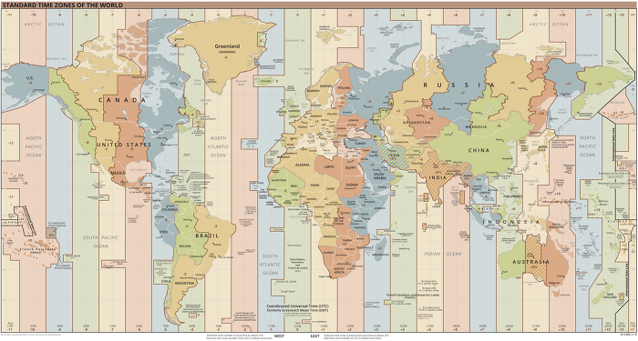

```python
Image(bpc.UTC_TimeZone)
```

```python
ts_utc = ts.tz_localize('UTC')
ts_utc
```

```
2022-06-01 00:00:00+00:00    0.461017
2022-06-02 00:00:00+00:00   -0.331771
2022-06-03 00:00:00+00:00    1.946579
2022-06-04 00:00:00+00:00   -0.882212
2022-06-05 00:00:00+00:00   -0.969700
Freq: D, dtype: float64
```

```python
# 다른 시간대로 변환
ts_utc.tz_convert('US/Eastern')
```

```
2022-05-31 20:00:00-04:00    0.461017
2022-06-01 20:00:00-04:00   -0.331771
2022-06-02 20:00:00-04:00    1.946579
2022-06-03 20:00:00-04:00   -0.882212
2022-06-04 20:00:00-04:00   -0.969700
Freq: D, dtype: float64
```

```python
# 시간 표현 ↔ 기간 표현으로 변환
rng = pd.date_range('1/1/2022', periods=12, freq='M')
rng
```

```
DatetimeIndex(['2022-01-31', '2022-02-28', '2022-03-31', '2022-04-30',
               '2022-05-31', '2022-06-30', '2022-07-31', '2022-08-31',
               '2022-09-30', '2022-10-31', '2022-11-30', '2022-12-31'],
              dtype='datetime64[ns]', freq='M')
```

```python
ts = pd.Series(np.random.randn(len(rng)), index=rng)
ts
```

```
2022-01-31    0.905756
2022-02-28   -0.483320
2022-03-31   -0.023235
2022-04-30    0.334406
2022-05-31   -0.763138
2022-06-30    0.938486
2022-07-31    0.640078
2022-08-31    0.077728
2022-09-30    1.483144
2022-10-31   -0.225375
2022-11-30    1.101515
2022-12-31    0.409357
Freq: M, dtype: float64
```

```python
ps = ts.to_period()
ps
```

```
2022-01    0.905756
2022-02   -0.483320
2022-03   -0.023235
2022-04    0.334406
2022-05   -0.763138
2022-06    0.938486
2022-07    0.640078
2022-08    0.077728
2022-09    1.483144
2022-10   -0.225375
2022-11    1.101515
2022-12    0.409357
Freq: M, dtype: float64
```

```python
ps.to_timestamp()
```

```
2022-01-01    0.905756
2022-02-01   -0.483320
2022-03-01   -0.023235
2022-04-01    0.334406
2022-05-01   -0.763138
2022-06-01    0.938486
2022-07-01    0.640078
2022-08-01    0.077728
2022-09-01    1.483144
2022-10-01   -0.225375
2022-11-01    1.101515
2022-12-01    0.409357
Freq: MS, dtype: float64
```

```python
prng = pd.period_range('2012Q1', '2022Q4', freq='Q-NOV')
prng
```

```
PeriodIndex(['2012Q1', '2012Q2', '2012Q3', '2012Q4', '2013Q1', '2013Q2',
             '2013Q3', '2013Q4', '2014Q1', '2014Q2', '2014Q3', '2014Q4',
             '2015Q1', '2015Q2', '2015Q3', '2015Q4', '2016Q1', '2016Q2',
             '2016Q3', '2016Q4', '2017Q1', '2017Q2', '2017Q3', '2017Q4',
             '2018Q1', '2018Q2', '2018Q3', '2018Q4', '2019Q1', '2019Q2',
             '2019Q3', '2019Q4', '2020Q1', '2020Q2', '2020Q3', '2020Q4',
             '2021Q1', '2021Q2', '2021Q3', '2021Q4', '2022Q1', '2022Q2',
             '2022Q3', '2022Q4'],
            dtype='period[Q-NOV]')
```

```python
ts = pd.Series(np.random.randn(len(prng)), prng)
ts
```

```
2012Q1   -0.102828
2012Q2   -0.583223
2012Q3    0.823461
2012Q4    1.642493
2013Q1   -0.109604
2013Q2   -0.072970
2013Q3   -0.724602
2013Q4   -1.831548
2014Q1    1.293124
2014Q2   -0.420162
2014Q3   -0.214043
2014Q4   -0.297717
2015Q1    0.994883
2015Q2   -0.150721
2015Q3   -0.938455
2015Q4   -0.137537
2016Q1   -1.334032
2016Q2   -0.703199
2016Q3    0.326729
2016Q4    1.001844
2017Q1    0.093450
2017Q2    0.901941
2017Q3    0.838102
2017Q4   -0.857272
2018Q1   -2.301189
2018Q2   -0.214235
2018Q3    0.179304
2018Q4    1.355325
2019Q1   -0.828430
2019Q2    0.991926
2019Q3   -0.626720
2019Q4   -0.214144
2020Q1    1.521191
2020Q2   -0.608474
2020Q3    0.642326
2020Q4   -0.842995
2021Q1    0.203904
2021Q2    0.751754
2021Q3    0.742370
2021Q4    0.193555
2022Q1    0.291921
2022Q2    0.086862
2022Q3   -0.214434
2022Q4   -0.048908
Freq: Q-NOV, dtype: float64
```

```python
# help(prng.asfreq)
```

```python
prng
```

```
PeriodIndex(['2012Q1', '2012Q2', '2012Q3', '2012Q4', '2013Q1', '2013Q2',
             '2013Q3', '2013Q4', '2014Q1', '2014Q2', '2014Q3', '2014Q4',
             '2015Q1', '2015Q2', '2015Q3', '2015Q4', '2016Q1', '2016Q2',
             '2016Q3', '2016Q4', '2017Q1', '2017Q2', '2017Q3', '2017Q4',
             '2018Q1', '2018Q2', '2018Q3', '2018Q4', '2019Q1', '2019Q2',
             '2019Q3', '2019Q4', '2020Q1', '2020Q2', '2020Q3', '2020Q4',
             '2021Q1', '2021Q2', '2021Q3', '2021Q4', '2022Q1', '2022Q2',
             '2022Q3', '2022Q4'],
            dtype='period[Q-NOV]')
```

```python
ts.index = (prng.asfreq('M', 'e') + 1).asfreq('H', 's') + 9
ts.index
```

```
PeriodIndex(['2012-03-01 09:00', '2012-06-01 09:00', '2012-09-01 09:00',
             '2012-12-01 09:00', '2013-03-01 09:00', '2013-06-01 09:00',
             '2013-09-01 09:00', '2013-12-01 09:00', '2014-03-01 09:00',
             '2014-06-01 09:00', '2014-09-01 09:00', '2014-12-01 09:00',
             '2015-03-01 09:00', '2015-06-01 09:00', '2015-09-01 09:00',
             '2015-12-01 09:00', '2016-03-01 09:00', '2016-06-01 09:00',
             '2016-09-01 09:00', '2016-12-01 09:00', '2017-03-01 09:00',
             '2017-06-01 09:00', '2017-09-01 09:00', '2017-12-01 09:00',
             '2018-03-01 09:00', '2018-06-01 09:00', '2018-09-01 09:00',
             '2018-12-01 09:00', '2019-03-01 09:00', '2019-06-01 09:00',
             '2019-09-01 09:00', '2019-12-01 09:00', '2020-03-01 09:00',
             '2020-06-01 09:00', '2020-09-01 09:00', '2020-12-01 09:00',
             '2021-03-01 09:00', '2021-06-01 09:00', '2021-09-01 09:00',
             '2021-12-01 09:00', '2022-03-01 09:00', '2022-06-01 09:00',
             '2022-09-01 09:00', '2022-12-01 09:00'],
            dtype='period[H]')
```

```python
ts.head()
```

```
2012-03-01 09:00   -0.102828
2012-06-01 09:00   -0.583223
2012-09-01 09:00    0.823461
2012-12-01 09:00    1.642493
2013-03-01 09:00   -0.109604
Freq: H, dtype: float64
```

## 10. Categoricals (범주화)

> - Pandas는 데이터프레임 내에 범주형 데이터를 포함할 수 있습니다.
> - 범주형 소개 와 API 문서 부분을 참조하세요.

```python
df = pd.DataFrame({"id":[1,2,3,4,5,6], "raw_grade":['a', 'b', 'b', 'a', 'd', 'e']})
df
```

|  | id | raw_grade |
| --- | --- | --- |
| 0 | 1 | a |
| 1 | 2 | b |
| 2 | 3 | b |
| 3 | 4 | a |
| 4 | 5 | d |
| 5 | 6 | e |

```python
df["grade"] = df["raw_grade"].astype("category")
df
```

|  | id | raw_grade | grade |
| --- | --- | --- | --- |
| 0 | 1 | a | a |
| 1 | 2 | b | b |
| 2 | 3 | b | b |
| 3 | 4 | a | a |
| 4 | 5 | d | d |
| 5 | 6 | e | e |

```python
df["grade"]
```

```
0    a
1    b
2    b
3    a
4    d
5    e
Name: grade, dtype: category
Categories (4, object): ['a', 'b', 'd', 'e']
```

```python
df["grade"].cat.categories = ["very good", "good", "bad", "very bad"]
df
```

|  | id | raw_grade | grade |
| --- | --- | --- | --- |
| 0 | 1 | a | very good |
| 1 | 2 | b | good |
| 2 | 3 | b | good |
| 3 | 4 | a | very good |
| 4 | 5 | d | bad |
| 5 | 6 | e | very bad |

```python
df["grade"] = df["grade"].cat.set_categories(["very bad", "bad", "medium", "good", "very good"])
df
```

|  | id | raw_grade | grade |
| --- | --- | --- | --- |
| 0 | 1 | a | very good |
| 1 | 2 | b | good |
| 2 | 3 | b | good |
| 3 | 4 | a | very good |
| 4 | 5 | d | bad |
| 5 | 6 | e | very bad |

```python
df["grade"]
```

```
0    very good
1         good
2         good
3    very good
4          bad
5     very bad
Name: grade, dtype: category
Categories (5, object): ['very bad', 'bad', 'medium', 'good', 'very good']
```

```python
df.sort_values(by="grade")
```

|  | id | raw_grade | grade |
| --- | --- | --- | --- |
| 5 | 6 | e | very bad |
| 4 | 5 | d | bad |
| 1 | 2 | b | good |
| 2 | 3 | b | good |
| 0 | 1 | a | very good |
| 3 | 4 | a | very good |

```python
# 범주의 열을 기준으로 그룹화하면 빈 범주도 표시
df.groupby("grade").size()
```

```
grade
very bad     1
bad          1
medium       0
good         2
very good    2
dtype: int64
```

The BigpyCraft find the information to design valuable society with Technology & Craft.

< The End >